# Suicides by year visualization

Ronan

20/11/2020

```r
library(tidyverse)
```

```r
library(ggplot2)
library(webshot)
suicides <- read_csv("../data/master.csv")
suicides_clean <- suicides %>%
  rename(hdi = 'HDI for year',
         suicides_per_100k_pop = 'suicides/100k pop',
         country_year = 'country-year',
         gdp ='gdp_for_year ($)',
         gdp_per_capita = 'gdp_per_capita ($)')
 view(suicides_clean)
```

We will first look at the whole dataset to see if there is any overarching trends.

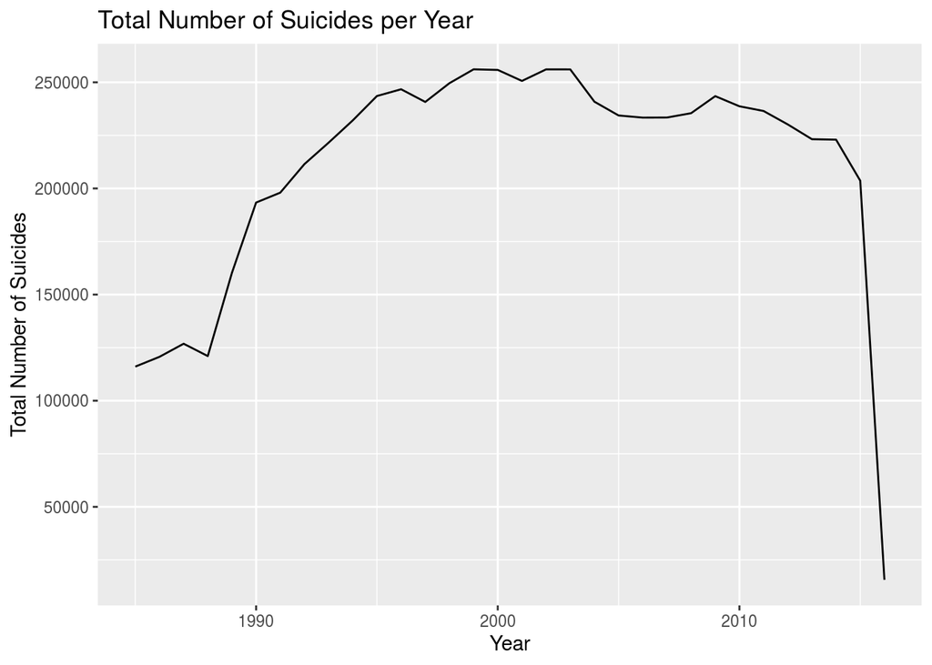

```r
suicides_clean %>%
  group_by(year) %>%
  summarise(n = sum(suicides_no)) %>%
  ggplot(mapping = aes(x = year, y = n)) +
  geom_line() +
  labs(title = "Total Number of Suicides per Year",
       x = "Year",
       y = "Total Number of Suicides"
       )
```

The suicide rates is much lower for the 1980s and 2016. This is probably not an actual trend but is due to the lack of data in the dataset. Some countries won’t have data for the outlying years so the suicides won’t be counted making it seem like the suicide rates were lower. We can check this by searching for the first year there is data for a certain country and the last year there is data for a certain country.

```r
suicides_clean %>%
  group_by(country) %>%
  summarise(first_year = min(year), last_year = max(year))
```

```
## # A tibble: 101 x 3
##    country             first_year last_year
##    <chr>                    <dbl>     <dbl>
##  1 Albania                   1987      2010
##  2 Antigua and Barbuda       1985      2015
##  3 Argentina                 1985      2015
##  4 Armenia                   1990      2016
##  5 Aruba                     1995      2011
##  6 Australia                 1985      2015
##  7 Austria                   1985      2016
##  8 Azerbaijan                1990      2007
##  9 Bahamas                   1985      2013
## 10 Bahrain                   1985      2014
## # … with 91 more rows
```

The first and last year a country appears in the dataset varies wildly so to avoid error in our visualizations we will have only focus on individual countries. Let’s analyze the countries with the highest suicide rates. First we must find out what these are.

```r
suicides_clean %>%
  group_by(country) %>%
  summarise(suicide_rates = mean(suicides_per_100k_pop)) %>%
  arrange(desc(suicide_rates))
```

```
## # A tibble: 101 x 2
##    country            suicide_rates
##    <chr>                      <dbl>
##  1 Lithuania                   40.4
##  2 Sri Lanka                   35.3
##  3 Russian Federation          34.9
##  4 Hungary                     32.8
##  5 Belarus                     31.1
##  6 Kazakhstan                  30.5
##  7 Latvia                      29.3
##  8 Slovenia                    27.8
##  9 Estonia                     27.3
## 10 Ukraine                     26.6
## # … with 91 more rows
```

8 out of the 10 countries with the highest average suicide rate are in eastern europe so this is a good area to focus on for our visualization.

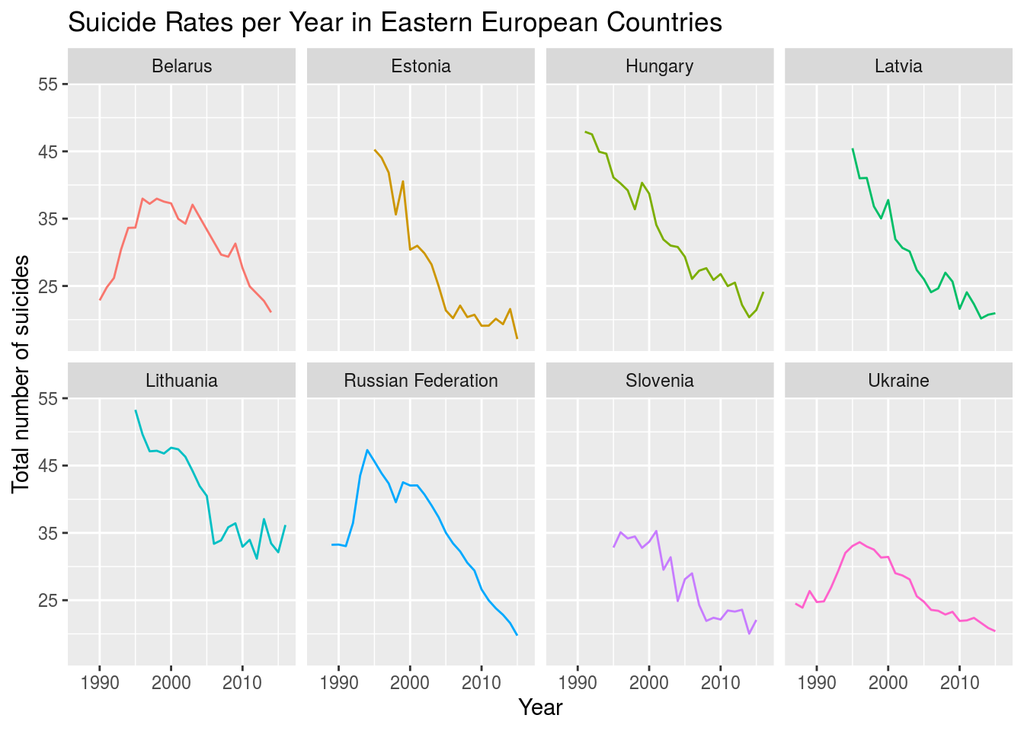

```r
suicides_clean %>%
  filter(country %in% c("Russian Federation", "Lithuania", "Hungary", "Belarus", "Latvia", "Estonia", "Ukraine", "Slovenia")) %>%
  group_by(year, country) %>%
  summarise(total_suicides = mean(suicides_per_100k_pop)) %>%
  ggplot(aes(x = year, y = total_suicides, color = country)) +
  geom_line() +
  facet_wrap(~ country, ncol = 4) +
  labs(title = "Suicide Rates per Year in Eastern European Countries",
       x = "Year",
       y = "Total number of suicides") +
  guides(color = FALSE)
```

As we can see there is an obvious downward trend in the suicide rate from 1995 to 2015. It is also interesting to note that 3 out of the 4 countries with data from 1990 onward have an initial upward trend going from 1990 to 1995.

There are many possible explanations for this trend that we can explore. One option is HDI. Our dataset does not have HDI information for Russia so we can use an outside source to compare it to.